# Biostatistical Computing, PHC 6068

Simulation study

Zhiguang Huo (Caleb)

Monday November 9, 2020

# Outlines

- Introduction
- Compare estimators
  - mean estimators
  - linear regression estimators
- Hypothesis testing
  - size
  - power
  - confidence intercal
- Permutation test
- Multiple testing
  - Bonferroni correction
  - False discovery rate

# What is a simulation study?

Simulation (a.k.a Monte Carlo simulation):

- Rely on repeated random samplings to obtain numerical results.

Why we need simulation studies

- After we propose a statistical method, we want to validate the method using simulation so people can use it with confidence.
- Exact analytical derivations of properties are rarely possible.

# Common questions simulation study can answer

- How does an estimator compare to its competing estimators on the basis of bias, mean square error, efficiency, etc.?
- Does a procedure for constructing a confidence interval for a parameter achieve the advertised nominal level of coverage?
- Does a hypothesis testing procedure attain the nominal (advertised) level of significance or size?
- How to estimate power from simulation study?

# How to approximate

Typical Monte Carlo simulation involves the following procedures:

1. Generate $B$ independent datasets $(1, 2, \ldots, B)$ under conditions of interest.
2. Compute the numerical value of an estimator/test statistic $T$ from each dataset. Then we have $T_1, T_2, \ldots, T_b, \ldots, T_B$.
3. If $B$ is large enough, summary statistics across $T_1, \ldots, T_B$ should be good approximations to the true properties of the estimator/test statistic.

Illustration:

$X \sim f(\theta)$, $T = T(X)$, where $T$ is an estimator, or a procedure

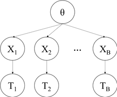

# Example 1, Compare estimators (normal distribution)

- Assume $X \sim N(\mu, \sigma^2)$ with $\mu = 1$ and $\sigma^2 = 1$.
- We want to compare three estimators for the mean $\mu$ of this distribution based on a random sample $X_1, X_2, \ldots, X_n$.
  - Sample Mean $T^{mean}$
  - Sample Median $T^{median}$
  - Sample 20% trimmed mean $T^{mean20\%}$

Note: 20% trimmed mean indicates average value after deleting first 10% quantile and last 10% quantile.

E.g. 1,2,…,10

- mean = mean(1:10)
- mean20% = mean(2:9)

# Evaluation criteria

k: estimator index, including: mean, median, mean20%

- $T^{(k)}$: estimator of interest
- Bias: $|E({T}^{(k)}) - \mu|$
- variance: $E[{T}^{(k)} - E({T}^{(k)})]^2$
- **Mean squared error**: $MSE = Bias^2 + vairance$
  - MSE is a commonly used criteria for evaluating estimators.
  - $MSE = E[{T}^{(k)} - \mu]^2$
- Relative efficiency
  - For any consistent estimator $T^{(1)}$, $T^{(2)}$, (i.e., $E(T^{(1)}) = E(T^{(2)}) = \mu$)
  - $RE(T^{(2)}, T^{(1)}) = \frac{MSE(T^{(1)})}{MSE(T^{(2)})}$
  - is the relative efficiency of estimator 2 to estimator 1.
  - $RE < 1$ means estimator 1 is preferred.

# $T^{mean}$

$$T^{mean} = \frac{1}{n}\sum_{i=1}^n X_i$$

- Bias: $|E({T}^{(mean)}) - \mu| = |\frac{1}{n}\sum_{i=1}^n \mu - \mu| = 0$
- Variance: $E[{T}^{(mean)} - E({T}^{(mean)})]^2 = \frac{\sigma^2}{n}$
- MSE: $MSE = Bias^2 + vairance = \frac{\sigma^2}{n}$

Can be calculated analytically

# $T^{median}$

$$T^{median} = Median_{i=1}^n X_i$$

- Bias: $|E({T}^{(median)}) - \mu| =0?$
- Variance: $E[{T}^{(median)} - E({T}^{(median)})]^2 =?$
- MSE: $MSE = Bias^2 + vairance =?$

Variance is hard to be calculated analytically

# $T^{mean20\%}$

Can be calculated

$$T^{mean20\%} = \frac{1}{0.8n}\sum_{i=0.1n+1}^{0.9n} X_i$$

- Bias: $| E({T}^{(mean20\%)}) - \mu| =0?$
- Variance: $E[{T}^{(mean20\%)} - E({T}^{(mean20\%)})]^2 =?$
- MSE: $MSE = Bias^2 + vairance =?$

Variance is hard to be calculated analytically

# Evaluation via simulation

No analytic solution, we can evaluate using simulation studies.

- Algorithm:
  1. Sample $n$ samples from $f$ (i.e., $N(\mu, \sigma^2)$)
  2. Calculate ${T}^{(k)}$, where $k$ is the estimator index
  3. Repeat Step 1,2 B times to obtain $T_1^{(k)}, \ldots, T_B^{(k)}$
  4. Evaluate the property of ${T}^{(k)}$ using the Monte Carlo samples $T_1^{(k)}, \ldots, T_B^{(k)}$.
- $\bar{T}^{(k)} = \frac{1}{B}\sum_{b=1}^B T_b^{(k)}$
- $\widehat{Bias} = |\bar{T}^{(k)} - \mu|$
- $\widehat{vairance} = \frac{1}{B - 1} \sum_{b=1}^B (T_b^{(k)} - \bar{T}^{(k)})^2$
- Mean squared error: $\widehat{MSE} = \widehat{Bias}^2 + \widehat{vairance}$
- Relative efficiency
  - For any consistent estimator $T^{(1)}$, $T^{(2)}$, (i.e., $E(T^{(1)}) = E(T^{(2)}) = \mu$)
  - $\widehat{RE} = \frac{\widehat{MSE}(T^{(1)})}{\widehat{MSE}(T^{(2)})}$
  - is the relative efficiency of estimator 2 to estimator 1.
  - $\widehat{RE} < 1$ means estimator 1 is preferred.

# Simulation experiment

```r
mu <- 1; B <- 1000; n <- 20

Ts <- matrix(0,nrow=B,ncol=3)
colnames(Ts) <- c("mean", "median", "mean 20% trim")


for(b in 1:B){
  set.seed(b)
  x <- rnorm(n, mean = mu)

  Ts[b,1] <- mean(x)
  Ts[b,2] <- median(x)
  Ts[b,3] <- mean(x, trim = 0.1)
}

bias <- abs(apply(Ts,2,function(x) mean(x) - mu))
vars <- apply(Ts,2,var)

MSE <- bias^2 + vars
RE <- MSE[1]/MSE

comparisonTable <- rbind(bias, vars, MSE, RE)
colnames(comparisonTable) <- c("mean", "median", "mean 20% trim")
comparisonTable
```

```
##              mean      median mean 20% trim
## bias 3.832736e-05 0.006673072   0.000688909
## vars 5.174830e-02 0.074680145   0.054550469
## MSE  5.174830e-02 0.074724675   0.054550944
## RE   1.000000e+00 0.692519633   0.948623449
```

# Difference between simulation and real data application

- In simulation
  - Know the underlying truth (e.g., $\mu$)
  - Can evaluate the performance of our estimator/procedure (e.g., $T$) by comparing to the underlying truth
- In real data application
  - There is no underlying truth

# Example 2, Compare estimators (exponential distribution)

- Assume $X \sim Exp(\mu)$ with $\mu = 1$.
  $$f(x) = \exp(-x), x\ge0$$
- We want to compare three estimators for the mean $\mu$ of this distribution based on a random sample $X_1, X_2, \ldots, X_n$.
  - Sample Mean $T^{mean}$
  - Sample Median $T^{median}$
  - Sample 20% trimmed mean $T^{mean20\%}$

# Simulation experiment

```r
mu <- 1; B <- 1000; n <- 20

Ts <- matrix(0,nrow=B,ncol=3)
colnames(Ts) <- c("mean", "median", "mean 20% trim")

for(b in 1:B){
  set.seed(b)
  x <- rexp(n, rate = mu)

  Ts[b,1] <- mean(x)
  Ts[b,2] <- median(x)
  Ts[b,3] <- mean(x, trim = 0.1)
}

bias <- abs(apply(Ts,2,function(x) mean(x) - mu))
vars <- apply(Ts,2,var)

MSE <- bias^2 + vars
RE <- MSE[1]/MSE

comparisonTable <- rbind(bias, vars, MSE, RE)
colnames(comparisonTable) <- c("mean", "median", "mean 20% trim")
comparisonTable
```

```
##            mean     median mean 20% trim
## bias 0.01040018 0.26539760    0.13243138
## vars 0.05021121 0.05052217    0.04247023
## MSE  0.05031938 0.12095806    0.06000830
## RE   1.00000000 0.41600681    0.83854029
```

# Example 3, Compare estimators (Cauchy distribution)

- Assume $X \sim Cauchy(\mu,\gamma)$ with $\mu = 0$ and $\gamma = 1$.
  $$f(x; \mu, \gamma) = \frac{1}{\pi (1 + x^2)}$$
- We want to compare three estimators for the mean $\mu$ of this distribution based on a random sample $X_1, X_2, \ldots, X_n$.
  - Sample Mean $T^{mean}$
  - Sample Median $T^{median}$
  - Sample 20% trimmed mean $T^{mean20\%}$

# Simulation experiment

```r
mu <- 0; B <- 1000; n <- 20

Ts <- matrix(0,nrow=B,ncol=3)
colnames(Ts) <- c("mean", "median", "mean 20% trim")

for(b in 1:B){
  set.seed(b)
  x <- rcauchy(n, location  = mu)

  Ts[b,1] <- mean(x)
  Ts[b,2] <- median(x)
  Ts[b,3] <- mean(x, trim = 0.1)
}

bias <- abs(apply(Ts,2,function(x) mean(x) - mu))
vars <- apply(Ts,2,var)

MSE <- bias^2 + vars
RE <- MSE[1]/MSE

comparisonTable <- rbind(bias, vars, MSE, RE)
colnames(comparisonTable) <- c("mean", "median", "mean 20% trim")
comparisonTable
```

```
##             mean       median mean 20% trim
## bias   0.1187952 5.811866e-03  2.969290e-03
## vars 742.5037597 1.467307e-01  3.738797e-01
## MSE  742.5178721 1.467645e-01  3.738885e-01
## RE     1.0000000 5.059247e+03  1.985934e+03
```

# UMVUE

- Uniformly minimum-variance unbiased estimator (UMVUE) is an unbiased estimator that has lower variance than any other unbiased estimator for all possible values of the parameter.
- Blue: the best linear unbiased estimator (BLUE) of the coefficients is given by the ordinary least squares (OLS) estimator,

$$\hat{\beta}^{ols} = \arg \min_\beta \frac{1}{2}\|y - X\beta\|^2_2$$

- Modern statistics care about both bias and variance of an estimator instead of only unbiased estimator.
- Lasso estimator

$$\hat{\beta}^{lasso} = \arg \min_\beta \frac{1}{2} \|y - X\beta\|^2_2 + \lambda \|\beta\|_1$$

# Example 4, evaluate bias, variance and MSE of OLS, lasso

Model setup:

- $\beta_0 = 1$, $\beta_1 = 3$, $\beta_2 = 5$, $\beta_3 = \beta_4 = \beta_5 = 0$
- $X_1, \ldots, X_5 \sim N(0,1)$
- $Y_0 = \beta_0 + X_1 \beta_1 + X_2 \beta_2 +\ldots, X_5 \beta_5$
- $Y = Y_0 + N(0,3^2)$
- $n = 30$

Goal:

- Wants to evaluate bias, variance and MSE of OLS, lasso estimators
- $bias(\beta, \hat{\beta})^2 = \sum_{j=0}^5 bias(\beta_j, \hat{\beta}_j)^2$
- $var_T(\hat{\beta}) = \sum_{j=0}^5 var(\hat{\beta}_j)$
- $MSE(\hat{\beta}) = bias(\beta, \hat{\beta})^2 + var_T(\hat{\beta})$

# For simulation of OLS (ordinary least square)

- Set $B = 1000$
- For $b (1 \le b \le B)$
  1. simulate $Y_b = Y_0 + N(0,3^2)$
  2. Calculate $\hat{\beta}^{ols}_b \in \mathbb{R}^6$
- Calculate $\hat{\bar{\beta}}^{ols} = \frac{1}{B}\sum_{b=1}^B \hat{\beta}^{ols}_b$
- Calculate bias $bias(\beta, \hat{\bar{\beta}}^{ols})^2 = \sum_{j=0}^5 bias(\beta_j, \hat{\bar{\beta}}^{ols}_j)^2$
- Calculate variance: $var(\hat{\beta}^{ols}_j) = \frac{1}{B-1} \sum_{b=1}^B (\hat{\beta_j}^{ols}_b - \hat{\bar{\beta}}_j^{ols})^2$ , $var_T(\hat{\beta}^{ols}) = \sum_{j=0}^5 var(\hat{\beta}^{ols}_j)$
- $MSE(\hat{\beta}^{ols}) = bias(\beta, \hat{\beta}^{ols})^2 + var_T(\hat{\beta}^{ols})$

# For simulation of lasso

- Set $B = 1000$
- For $b (1 \le b \le B)$, given a specific tuning parameter,
  1. simulate $Y_b = Y_0 + N(0,3^2)$
  2. Calculate $\hat{\beta}^{lasso}_b \in \mathbb{R}^6$
- Calculate $\hat{\bar{\beta}}^{lasso} = \frac{1}{B}\sum_{b=1}^B \hat{\beta}^{lasso}_b$
- Calculate bias $bias(\beta, \hat{\bar{\beta}}^{lasso})^2 = \sum_{j=0}^5 bias(\beta_j, \hat{\bar{\beta}}^{lasso}_j)^2$
- Calculate variance: $var(\hat{\beta}^{lasso}_j) = \frac{1}{B-1} \sum_{b=1}^B (\hat{\beta_j}^{lasso}_b - \hat{\bar{\beta}}_j^{lasso})^2$ , $var_T(\hat{\beta}^{lasso}) = \sum_{j=0}^5 var(\hat{\beta}^{lasso}_j)$
- $MSE(\hat{\beta}^{lasso}) = bias(\beta, \hat{\beta}^{lasso})^2 + var_T(\hat{\beta}^{lasso})$
- Repeat this procedure for all tuning parameters

# Simulation experiment

```r
library(lars)
beta0 <- 1; beta1 <- 3; beta2 <- 5
beta3 <- beta4 <- beta5 <- 0
beta <- c(beta0,beta1,beta2,beta3,beta4,beta5)
p <- 5; n <- 30
set.seed(32611)
X0 <- matrix(rnorm(p*n),nrow=n)
X <- cbind(1, X0) ## X fixed

Y0 <- X %*% as.matrix(beta, ncol=1)

B <- 1000
beta_ols <- replicate(n = B, expr = list())
beta_lasso <- replicate(n = B, expr = list())

for(b in 1:B){
  set.seed(b)

  error <- rnorm(length(Y0), sd = 3)
  Y <- Y0 + error

  abeta_ols <- lm(Y~X0)$coefficients
  beta_ols[[b]] <- abeta_ols

  alars <- lars(x = X, y = Y, intercept=F)
  beta_lasso[[b]] <- alars
}
```

# Simulation experiment (continue 2)

```r
beta_ols_hat <- Reduce("+",beta_ols)/length(beta_ols)
beta_ols_bias <- sqrt(sum((beta_ols_hat - beta)^2))
beta_ols_variance <-  sum(Reduce("+", lapply(beta_ols,function(x) (x - beta_ols_hat)^2))/(length(beta_ols) - 1))
beta_ols_MSE <- beta_ols_bias + beta_ols_variance

as <- seq(0,10,0.1)
lassoCoef <- lapply(beta_lasso, function(alars){
  alassoCoef <- t(coef(alars, s=as, mode="lambda"))
  alassoCoef
} )

beta_lasso_hat <- Reduce("+",lassoCoef)/length(lassoCoef)
beta_lasso_bias <- sqrt(colSums((beta_lasso_hat - beta)^2))
beta_lasso_variance <-  colSums(Reduce("+", lapply(lassoCoef,function(x) (x - beta_lasso_hat)^2))/(length(beta_ols) - 1))
beta_lasso_MSE <- beta_lasso_bias + beta_lasso_variance
```

# Simulation experiment (continue 3)

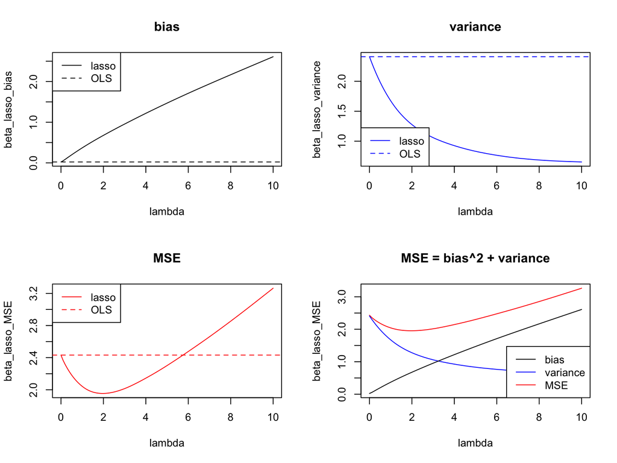

```r
par(mfrow=c(2,2))
plot(x = as, y = beta_lasso_bias, type = "l", xlab="lambda", main="bias")
abline(h = beta_ols_bias, lty=2)
legend("topleft", legend = c("lasso", "OLS"), col = 1, lty = c(1,2))

plot(x = as, y = beta_lasso_variance, col=4, type = "l", xlab="lambda", main="variance")
abline(h = beta_ols_variance, lty=2, col=4)
legend("bottomleft", legend = c("lasso", "OLS"), col = 4, lty = c(1,2))

plot(x = as, y = beta_lasso_MSE, col=2, type = "l", xlab="lambda", main="MSE")
abline(h = beta_ols_MSE, lty=2, col=2)
legend("topleft", legend = c("lasso", "OLS"), col = 2, lty = c(1,2))


plot(x = as, y = beta_lasso_MSE, ylim = c(min(beta_lasso_bias), max(beta_lasso_MSE)),
     type="n", xlab="lambda", main="MSE = bias^2 + variance")
lines(x = as, y = beta_lasso_MSE, type = "l", col=2)
lines(x = as, y = beta_lasso_variance, col=4)
lines(x = as, y = beta_lasso_bias, col=1)
legend("bottomright", legend = c("bias", "variance", "MSE"), col = c(1,4,2), lty = c(1))
```

# Tuning parameter selection for lasso?

1. Split the data to part A and part B.
2. Using part A, find the tuning parameter such that the MSE is minimized.
3. Evaluate the performance (with the tuning parameter in [2]) using part B.

# Hypothesis testing (one-sided)

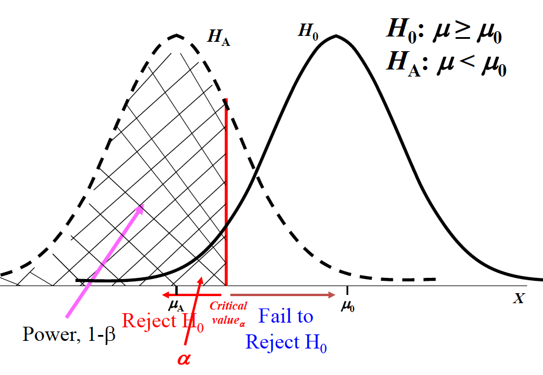

# Hypothesis testing (two-sided)

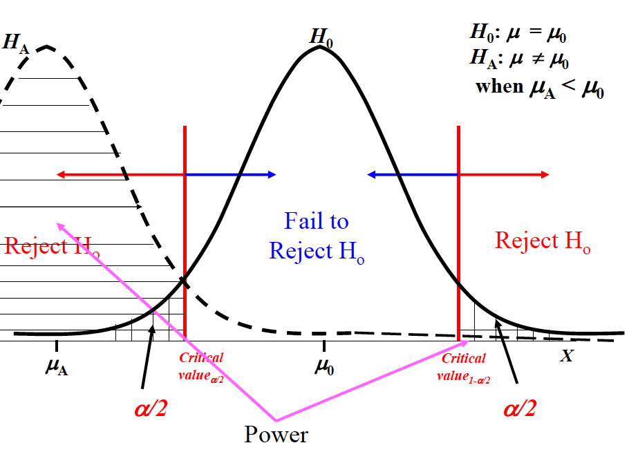

# Does a hypothesis testing procedure attain the nominal (advertised) level of significance or size?

Consider the following tests:

- Parametric: t.test()
- Non-Parametric: wilcox.test()

# Simulation for sizes of hypothesis tests

- Test $H_0: \mu = \mu_0$ against $H_A: \mu \neq \mu_0$
- To evaluate whether size/level of test achieves advertised $\alpha$ under $H_0$
  - Generate data under $H_0: \mu = \mu_0$ and calculate the proportion of rejections of $H_0$
  - Proportion of rejecting $H_0$ approximately equals to $\alpha$

Consider using the following simulation setting

- n = 20 (number of samples)
- B = 1000 (number of simulations)
- alpha = 0.05
- two.sided test

# Example 5, t.test() size

- Test $H_0: \mu = 0$ against $H_A: \mu \neq 0$

```r
alpha <- 0.05; mu=0; n <- 20; B <- 1000

counts <- 0
for(b in 1:B){
  set.seed(b)

  x <- rnorm(n, mean=mu)
  atest <- t.test(x)

  if(atest$p.value < alpha){
    counts <- counts + 1
  }
}

counts/B
```

```
## [1] 0.05
```

# Example 6, wilcox.test() size

- Test $H_0: \mu = 0$ against $H_A: \mu \neq 0$

```r
alpha <- 0.05; mu=0; n <- 20; B <- 1000

counts <- 0
for(b in 1:B){
  set.seed(b)

  x <- rnorm(n, mean=mu)
  atest <- wilcox.test(x)

  if(atest$p.value < alpha){
    counts <- counts + 1
  }
}

counts/B
```

```
## [1] 0.047
```

# Example 7, t.test() only use first 10 samples size

- Test $H_0: \mu = 0$ against $H_A: \mu \neq 0$

```r
alpha <- 0.05; mu=0; n <- 20; B <- 1000

counts <- 0
for(b in 1:B){
  set.seed(b)

  x <- rnorm(n, mean=mu)[1:10]
  atest <- t.test(x)

  if(atest$p.value < alpha){
    counts <- counts + 1
  }
}

counts/B
```

```
## [1] 0.056
```

# Compare these test procedures

- If several tests has the same size, how to compare which test is better?
  - Compare power
- To evaluate power
  - Generate data under some alternatives, $\mu \neq \mu_0$ (i.e.,$\mu = \mu_1$) and calculate the proportion of rejections of $H_0$

# Example 8, t.test() power

- Test $H_0: \mu = 0$ against $H_A: \mu = 1$

```r
alpha <- 0.05; mu=0; mu1 <- 1; n <- 20; B <- 1000

counts <- 0
for(b in 1:B){
  set.seed(b)

  x <- rnorm(n, mean=mu1)
  atest <- t.test(x)

  if(atest$p.value < alpha){
    counts <- counts + 1
  }
}
counts / B
```

```
## [1] 0.985
```

# Example 8, Validate the result using R function

```r
library(pwr)
alpha <- 0.05; mu=0; mu1 <- 1; n <- 20; B <- 1000
pwr.t.test(n = n, d = mu1, sig.level = alpha, type = "one.sample", alternative = "two.sided")
```

```
##
##      One-sample t test power calculation
##
##               n = 20
##               d = 1
##       sig.level = 0.05
##           power = 0.9885913
##     alternative = two.sided
```

# Example 9, wilcox.test() power

- Test $H_0: \mu = 0$ against $H_A: \mu = 1$

```r
alpha <- 0.05; mu=0; mu1 <- 1; n <- 20; B <- 1000

counts <- 0
for(b in 1:B){
  set.seed(b)

  x <- rnorm(n, mean=mu1)
  atest <- wilcox.test(x)

  if(atest$p.value < alpha){
    counts <- counts + 1
  }
}
counts / B
```

```
## [1] 0.979
```

# Example 10, t.test() only use first 10 samples power

- Test $H_0: \mu = 0$ against $H_A: \mu = 1$

```r
alpha <- 0.05; mu=0; mu1 <- 1; n <- 20; B <- 1000

counts <- 0
for(b in 1:B){
  set.seed(b)

  x <- rnorm(n, mean=mu1)[1:10]
  atest <- t.test(x)

  if(atest$p.value < alpha){
    counts <- counts + 1
  }
}
counts / B
```

```
## [1] 0.805
```

In general, the larger sample sizes, the larger power.

# Example 10, Validate the result using R function

```r
alpha <- 0.05; mu=0; mu1 <- 1; n <- 20; B <- 1000
pwr.t.test(n = 10, d = mu1, sig.level = alpha, type = "one.sample", alternative = "two.sided")
```

```
##
##      One-sample t test power calculation
##
##               n = 10
##               d = 1
##       sig.level = 0.05
##           power = 0.8030969
##     alternative = two.sided
```

# Summary: Size and Power

- Size of a test: Generate data under $H_0$, at alpha level 0.05, the proportation of rejecting $H_0$ is the size of a test
- Power of a test: Generate data under $H_A$, at alpha level 0.05, the proportation of rejecting $H_0$ is the power of a test

# Confidence interval

A $1 - \alpha$ confidence interval for parameter $\mu$ is an interval $C_n = (a,b)$ where $a = a(X_1, \ldots, X_n)$ and $b = b(X_1, \ldots, X_n)$ are functions of the data such that
$$P(\mu \in C_n) \ge 1 - \alpha$$
In other words, $(a,b)$ traps $\mu$ with probability $1 - \alpha$. We call $1 - \alpha$ the coverage of the confidence interval.

Interpretation:

- A confidence interval is not a probability statement about $\mu$ since $\mu$ is a fixed quantity, not a random variable.
- if I repeat the experiment over and over, the interval will contain the parameter $\mu$ 95 percent of the time.

# Example 11, Confidence interval

- $\mu = 1$
- $n=10, i = 1, \ldots, n$
- $X_i \sim N(\mu, 1)$
- $95\%$ confidence interval of $\mu$: $(\bar{X} - qt(0.975, n-1) \times \frac{\hat{\sigma}}{\sqrt{n}}, \bar{X} + qt(0.975, n-1) \times \frac{\hat{\sigma}}{\sqrt{n}})$

```r
mu <- 1
B <- 1000
n <- 10

x <- rnorm(n, mean=mu)
c(mean(x) - qt(0.975, n-1) * sd(x) / sqrt(n), mean(x) + qt(0.975, n-1) * sd(x) / sqrt(n))
```

```
## [1] 0.400803 2.219041
```

```r
t.test(x)
```

```
##
##  One Sample t-test
##
## data:  x
## t = 3.2595, df = 9, p-value = 0.009847
## alternative hypothesis: true mean is not equal to 0
## 95 percent confidence interval:
##  0.400803 2.219041
## sample estimates:
## mean of x
##  1.309922
```

- Evaluate the performance of this CI
  - Whether the procedure will trap the true parameter 95% chances

```r
counts <- 0
for(b in 1:B){
  set.seed(b)

  x <- rnorm(n, mean=mu)
  atest <- t.test(x)

  if(atest$conf.int[1] < mu & mu < atest$conf.int[2]){
    counts <- counts + 1
  }
}

counts/B
```

```
## [1] 0.944
```

# Example 12, Confidence interval (using normal approximation, n=100)

- CI by normal approximation
- Performance for large $n$, (e.g., $n=100$)
- $\mu = 1$
- $n=100, i = 1, \ldots, N$
- $X_i \sim N(\mu, 1)$
- $95\%$ confidence interval: $(\bar{X} - 1.96 \times \frac{\hat{\sigma}}{\sqrt{n}}, \bar{X} + 1.96 \times \frac{\hat{\sigma}}{\sqrt{n}})$

```r
set.seed(32611)
B <- 1000 ## number of test
counts <- 0 ## number of accepted tests
n <- 100
mu <- 1
alpha <- 0.05
for(b in 1:B){
  x <- rnorm(n, mean=mu, sd = 1)
  lb <- mean(x) - qnorm(alpha/2, lower.tail = F) * sd(x)/sqrt(n)
  ub <- mean(x) + qnorm(alpha/2, lower.tail = F) * sd(x)/sqrt(n)
  if(lb < mu & ub > mu){
    counts <- counts + 1
  }
}
print(counts/B)
```

```
## [1] 0.945
```

# Example 12, Confidence interval (using normal approximation, n=10)

- behavior in small sample sizes (e.g., $n=10$)
- $\mu = 1$
- $n=10, i = 1, \ldots, N$
- $X_i \sim N(\mu, 1)$
- $95\%$ confidence interval: $(\bar{X} - 1.96 \times \frac{\hat{\sigma}}{\sqrt{n}}, \bar{X} + 1.96 \times \frac{\hat{\sigma}}{\sqrt{n}})$

```r
set.seed(32611)
B <- 1000 ## number of test
counts <- 0 ## number of accepted tests
n <- 10
mu <- 1
alpha <- 0.05
for(b in 1:B){
  x <- rnorm(n, mean=mu, sd = 1)
  lb <- mean(x) - qnorm(alpha/2, lower.tail = F) * sd(x)/sqrt(n)
  ub <- mean(x) + qnorm(alpha/2, lower.tail = F) * sd(x)/sqrt(n)
  if(lb < mu & ub > mu){
    counts <- counts + 1
  }
}
print(counts/B)
```

```
## [1] 0.909
```

# Multiple testing

- Say you have a set of hypothesis that you want to test simultaneously.
- The first idea is to test each hypothesis separately, using a same significance $\alpha$.
- i.e.,You have 20 hypothesis to test at a significance level $\alpha = 0.05$. What is the probability of observing at least one significant result just due to chance?

$\begin{aligned} P(\mbox{at least one significant result}) &= 1 - P(\mbox{no significant result}) \\ & = 1 - (1 - 0.05)^{20} \\ & \approx 0.64 \\ \end{aligned}$

- i.e.,In genomic study, say you are tesing 10,000 genes and all of them are non-significant. At $\alpha$ level $0.05$, by chance you will declare 500 sigfinicant genes.

# Bonferroni correction

- Bonferroni correction controls the familywise error rate.
  - Bonferroni corrected p-value is the pvalue for at least one significant result
- The Bonferroni correction sets the significance cut-off at $\alpha / n$.
- In the previous example with 20 tests and $\alpha = 0.05$, we will only reject a null hypothesis if the p-value is less than 0.0025.

$\begin{aligned} P(\mbox{at least one significant result}) &= 1 - P(\mbox{no significant result}) \\ & = 1 - (1 - 0.0025)^{20} \\ & \approx 0.0488 \\ \end{aligned}$

- Bonferroni correction tends to be a bit too conservative (and very conservative if the samples are correlated).

# Simulation experiment

Under the null hypothesis, the p-values follow $U(0,1)$.

```r
B <- 1000
n <- 20 ## number of tests
N <- 15 ## number of samples per test
alpha <- 0.05

count <- 0
for(b in 1:B){
  set.seed(b)
  ax <- replicate(n, rnorm(N),simplify = F)
  ap <- sapply(ax,function(avec) t.test(avec)$p.value)

  if(any(ap < alpha/n)){
    count <- count + 1
  }
}
count/B
```

```
## [1] 0.045
```

# False discovery rate

- raw $\alpha$ level: doesn’t control for multiple comparison. False positive by chance. Too loose.
- Bonferroni correction: among all tests for samples from null distribution, the probability to falsely reject at least one sample is $\alpha$. Too stringent.
- False discover rate (FDR)
  - Also known as Benjamini-Hochberg correction
  - This is defined as the proportion of false positives among all significant results.

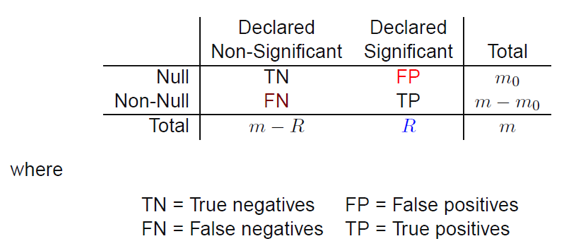

- Control $FDR = FP/R$ within a pre-specified range.

# Simulation setting

```r
B1 <- 9000
B2 <- 1000
B <- B1 + B2
n <- 10

SigLabel <- c(rep(F,  B1), rep(T, B2))

pval <- numeric(B)

for(b in 1:B){
    set.seed(b)
    if(b <= B1){
    x <- rnorm(n)
  } else {
    x <- rnorm(n, mean = 2)
  }

  pval[b] <- t.test(x=x)$p.value
}
```

# False discovery rate example

```r
qvalue <- p.adjust(pval, "BH")
test_fdr <- qvalue < 0.05
table_fdr <- table(SigLabel, test_fdr)
table_fdr
```

```
##         test_fdr
## SigLabel FALSE TRUE
##    FALSE  8951   49
##    TRUE     27  973
```

```r
fpr_fdr <-  sum(test_fdr & !SigLabel) / sum(test_fdr)
fpr_fdr
```

```
## [1] 0.04794521
```

# Comparison - raw p-value

```r
test_raw <- pval < 0.05
table_raw <- table(SigLabel, test_raw)
table_raw
```

```
##         test_raw
## SigLabel FALSE TRUE
##    FALSE  8562  438
##    TRUE      0 1000
```

```r
fpr_raw <-  sum(test_raw & !SigLabel) / sum(test_raw)
fnr_raw <-  sum(!test_raw & SigLabel) / sum(!test_raw)
fpr_raw
```

```
## [1] 0.3045897
```

```r
fnr_raw
```

```
## [1] 0
```

# Comparison - bonferroni correction

```r
test_bonferroni <- pval < 0.05/length(pval)
table_bonferroni <- table(SigLabel, test_bonferroni)
table_bonferroni
```

```
##         test_bonferroni
## SigLabel FALSE TRUE
##    FALSE  9000    0
##    TRUE    862  138
```

```r
fpr_bonferroni <-  sum(test_bonferroni & !SigLabel) / sum(test_bonferroni)
fnr_bonferroni <- sum(!test_bonferroni & SigLabel) / sum(!test_bonferroni)
fpr_bonferroni
```

```
## [1] 0
```

```r
fnr_bonferroni
```

```
## [1] 0.08740621
```

# Comparison - false discovery rate

```r
qvalue <- p.adjust(pval, "BH")
test_fdr <- qvalue < 0.05
table_fdr <- table(SigLabel, test_fdr)
table_fdr
```

```
##         test_fdr
## SigLabel FALSE TRUE
##    FALSE  8951   49
##    TRUE     27  973
```

```r
fpr_fdr <-  sum(test_fdr & !SigLabel) / sum(test_fdr)
fnr_fdr <- sum(!test_fdr & SigLabel) / sum(!test_fdr)
fpr_fdr
```

```
## [1] 0.04794521
```

```r
fnr_fdr
```

```
## [1] 0.003007351
```

# Principle for simulation study

1. A Monte Carlo simulation is just like any other experiment
   - Factors that are of interest to vary in the experiment: sample size n, distribution of the data, magnitude of variation…
   - Each combination of factors is a separate simulation, so that many factors can lead to very large number of combinations and thus number of simulations (time consuming)
   - Results must be recorded and saved in a systematic way
   - Don’t only choose factors favorable to a method you have developed!
   - Sample size B (number of data sets) must deliver acceptable precision.
2. Save everything!
   - Save the individual estimates in a file and then analyze
   - as opposed to computing these summaries and saving only them
   - Critical if the simulation takes a long time to run!
3. Keep B small at first
   - Test and refine code until you are sure everything is working correctly before carrying out final production runs
   - Get an idea of how long it takes to process one data set
4. Set a different seed for each run and keep records
   - Ensure simulation runs are independent
   - Runs may be replicated if necessary
5. Document your code

# Reference

- https://www.stat.nus.edu.sg/~stazjt/teaching/ST2137/lecture/lec%2011.pdf
- http://www4.stat.ncsu.edu/~davidian/st810a/simulation_handout.pdf